# Report VCT/PCT task results

# Statistical Analysis

This is a document that converts the results of the PCT (so far) to prose.

A Bayesian logistic regression was run `language ~ stim_language*phoneme*frame + (1 | participant), data = all_pct)`, where the outcome was language (either English or Spanish, coded as 1 and 0). The preditors were `stim_language` (either French or German), `phoneme` (i, o, schwa or y) and `frame` (fricative or bilabial).

The priors were the default (weakly informative priors), and the model was run using brms using all other defaults.

# Results

[figure not shown]

Number of participants

```
## [1] 27
```

List of each participant with number of trials each

| participant | n |
| --- | --- |
| 565a4547c51d43000587507d | 80 |
| 5898b6e256357700011c2c6b | 80 |
| 5a5479b4ac56240001537ffa | 92 |
| 5bcc60b95c2b810001dc68e2 | 80 |
| 5bebd4111296920001d55c5a | 92 |
| 5c2fae74d76cde0001c11590 | 92 |
| 5dc483cf74939e34e55c3619 | 92 |
| 5ddc07391e42a9000b2622be | 80 |
| 5e169361afb8b0c69c239371 | 80 |
| 5e27868c5cbbcc0b3599574b | 80 |
| 5ef9df1812148a78af8e76dc | 80 |
| 5f9057735c69b00e72665f84 | 92 |
| 5ff5f7ad932d56101bf7c90d | 80 |
| 5ffe6b8b773ec452c1d28adc | 80 |
| 600dd1ea271cf06201979123 | 80 |
| 60121fca666552254559110d | 80 |
| 601e1253bbecc3279e4fb472 | 80 |
| 60bc18bb8b971280ef13060c | 80 |
| 60c24c8ec01a8596ba5c8b85 | 104 |
| 60e1d5f866e681d7e33fd01c | 80 |
| 60f83b167c76803d88b92d53 | 92 |
| 60fe4c46e72a8b28dc55d376 | 80 |
| 6105ac9411551a0880809277 | 80 |
| 61094c7cb8c79b6a734c2d0c | 80 |
| 6109ab59c73e95d7a1f004a5 | 80 |
| 6124d122d91be3f612508804 | 106 |
| 6125b040ffa3c0b9e67b92c9 | 92 |

Number of responses per language across all stimuli

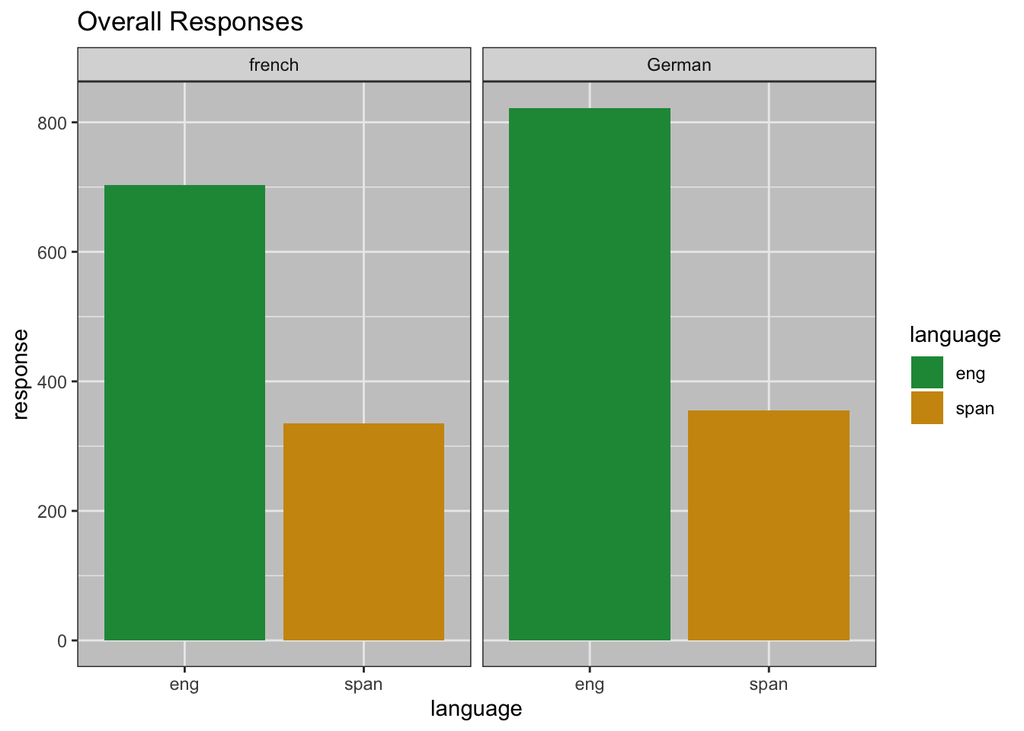

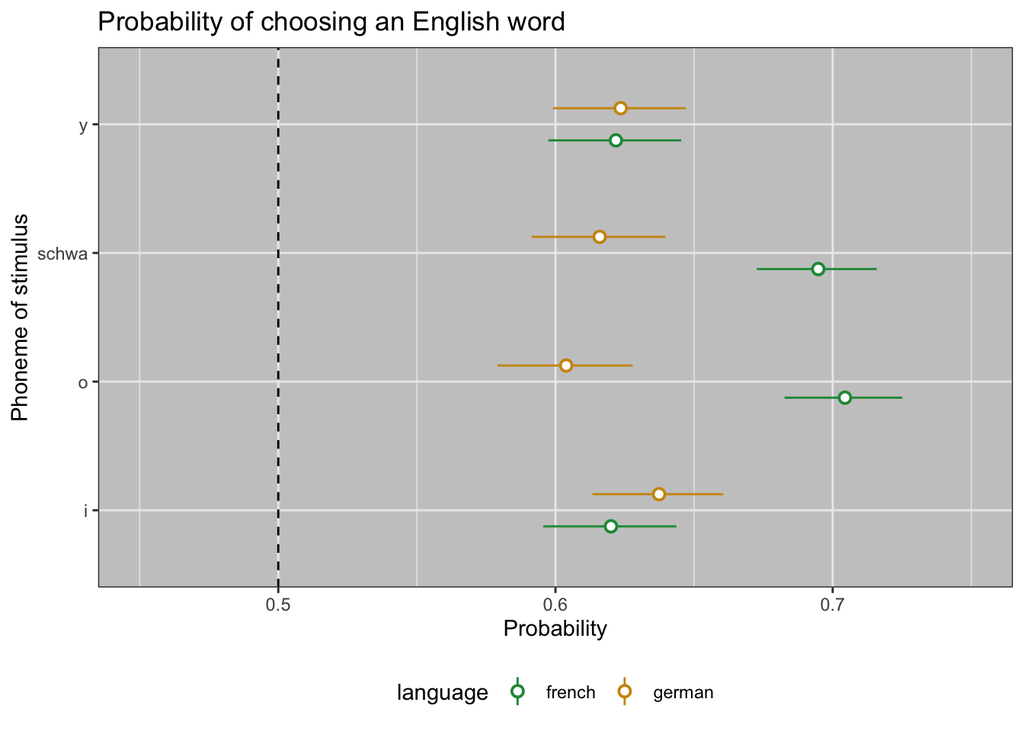

# check how many phonemes total were presented

```
## # A tibble: 4 x 2
##   phoneme     n
##   <chr>   <int>
## 1 i         540
## 2 o         607
## 3 schwa     607
## 4 y         540
```

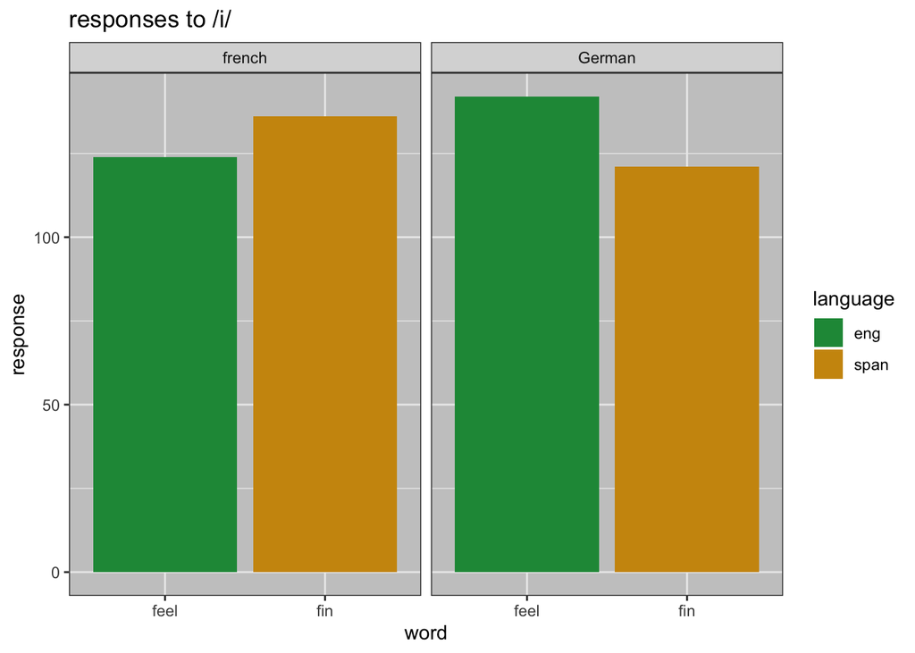

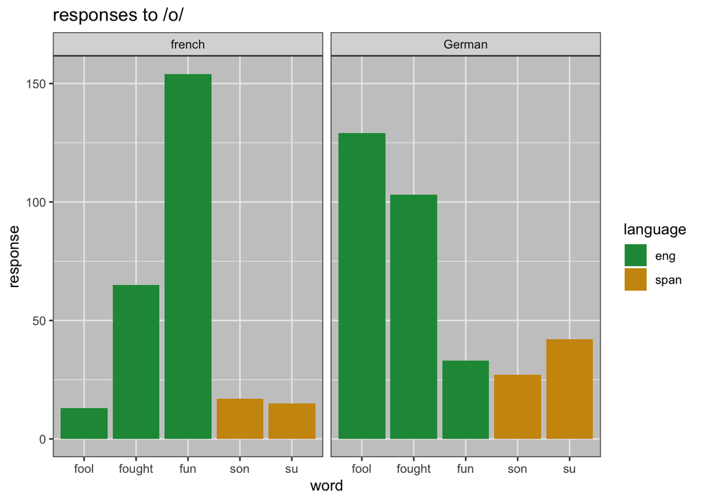

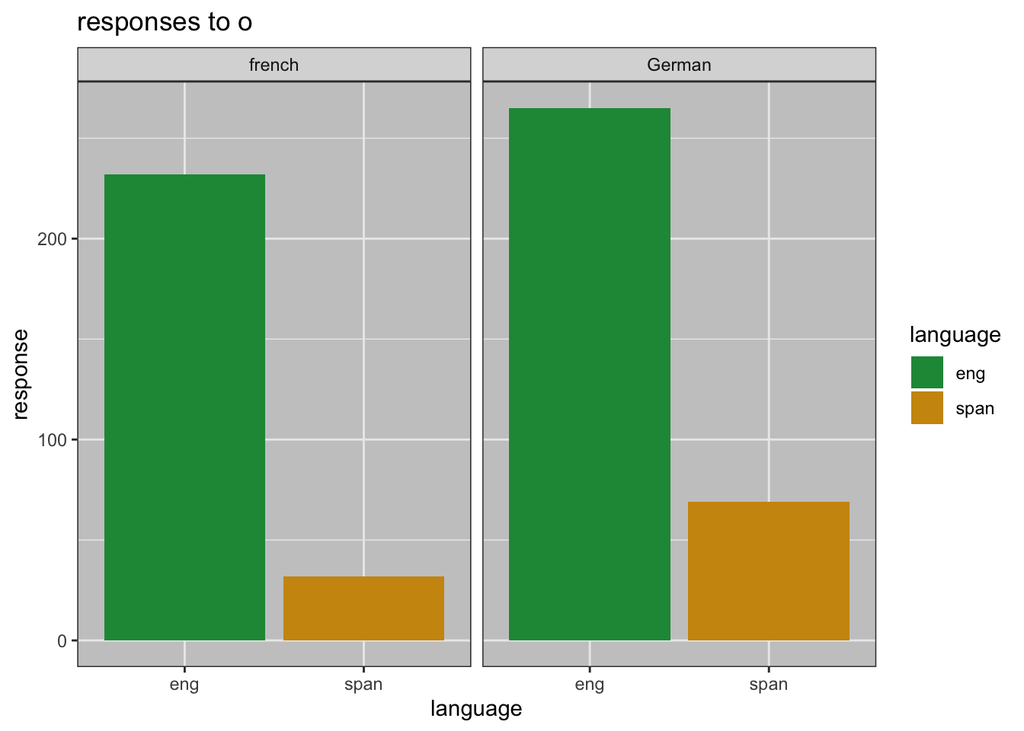

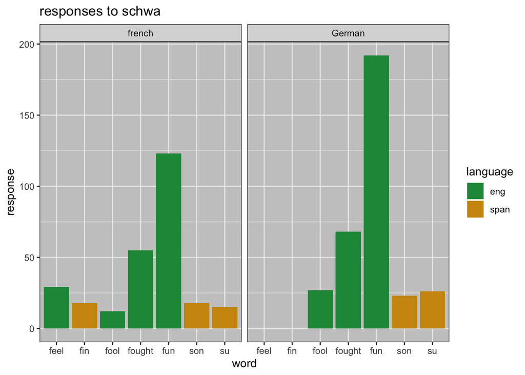

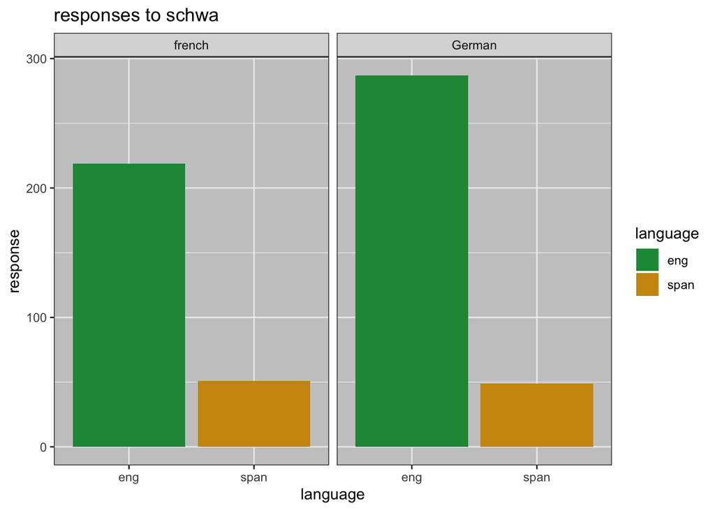

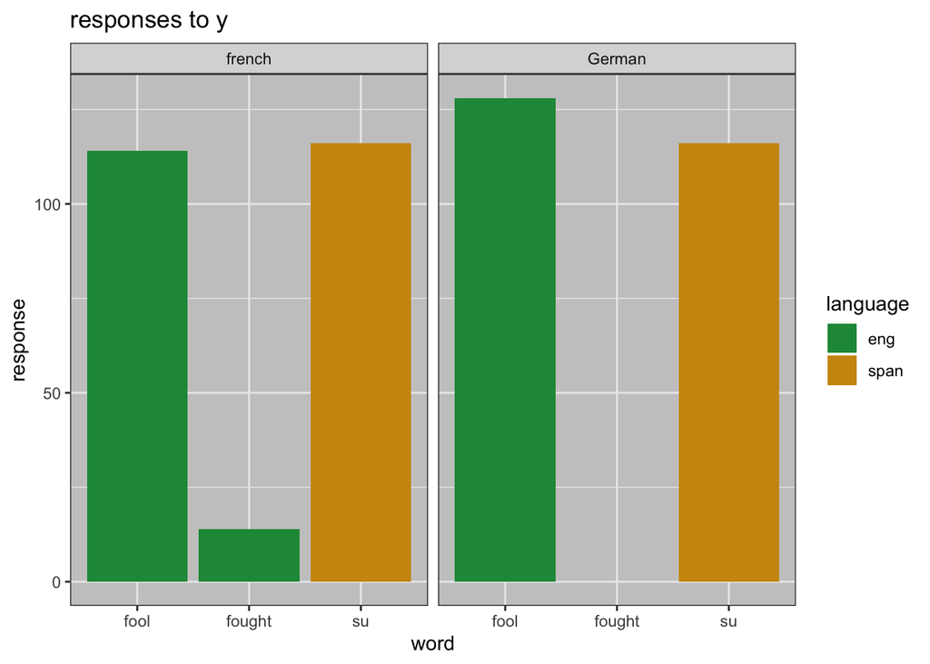